# An Investigation on the Change in Electricity Generation Mix in the US over Time

William Stein

5/4/2020

# Research Question

How has the mix of electricity generation sources changed in the US over time to become more sustainable?

# Discussion of Data Sources

The data given within the file titled, “Net Generation by State by Type of Producer by Energy Source” (https://www.eia.gov/electricity/data/state/) is recorded in the form of an Excel file and is the original data. This data set contains net electricity generation information per generation source by state. When analyzing this data, my primary intent is to visually represent the net change in electricity production, likely in the form of a line plot in order to show a decrease in production from less sustainable energy sourcing methods (demonstrated below).

Furthermore, the above data set title, “Fossil Fuel Consumption for Electricity Generation by Year, Industry Type and State” (https://www.eia.gov/electricity/data/state/), contains net electricity consumption data per generation source by state and is represented using an Excel file in its original form. Similarly to the electricity generation data set, my intent is to represent the net change in electricity consumption in the form of some line or lollipop plot in order to show a change in consumption over time.

In addition, the data set, “Financial Data on Publicly Owned Electric Utilities with Generation Facilities by State” (https://www.eia.gov/electricity/data/state/), contains state expenditure data between the years 2001 to 2003, showing the funding that public generating utilities have received from state governments. In addition to investment and operating expenses per state, this data set contains information pertaining to operating revenue, maintenance, and depreciation. All information within this excel file is original and has been obtained from the EIA.

Despite the scope of this assignment, further research beyond this project suggests that a global perspective be assumed; for instance, as opposed to focusing on energy sourcing developement within the United States, global projects may be considered.

One data source which may be considered in the future is the US Department of Energy (DOE). The DOE is a credible source as it is a government agency that partners with various credible laboratories who are responsible in assisting with data collection and analysis. For instance, several partner companies include Sandia National Laboratories, Pacific Northwest, and Oak Ridge National Laboratory.

This data set titled, “Global Energy Storage Database Projects” (https://www.sandia.gov/ess-ssl/global-energy-storage-database-home/), contains global energy storage projects and affiliated data, such as a description of the project, funding, fund providers, etc. Within this data set, I ultimately would select the “state” and “country” columns, in addition to the “funding amount” column. The purpose for the usage of this data within future projects might be to support the argument being made from the previous financial data set from the EIA. Likewise, this data set would take a more global perspective and compare how the United States energy development compares to those of other countries.

# Preliminary Insight

To give a preliminary view of the message being portrayed throughout this study, the first plot below demonstrates the inverse relationship between electricity generated due to coal versus wind within the United States from 1990 to 2018. Here, one may observe that development for wind generation technology was generally non-existent until the year 2006. Until then, with a growing population and higher demand for electricity, coal production increased as it was the primary electricity sourcing method. However, in 2006, energy sourcing methods shifted and technological advancement for wind increased (which is seen by the vertical dashed line in the plot below).

The purpose of this graph is not only to highlight the inverse relationship between coal and wind production, but to set up this study to show that 2006 was the year when changes in electricity sourcing methods occurred. These alterations occurred in part due to government intervention. One report from the US Department of Energy confirms that in 2007, the US government, in partnership with the wind energy industry, has elected to increase funding to further wind technology development.

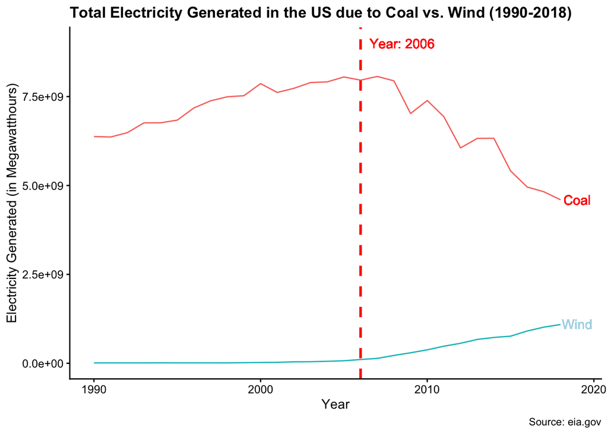

# In-depth Analysis

This section of the report aims to provide an in-depth view of how the mix of energy generation sources within the United States has evolved between 1990 and 2018. This is done by focusing on the inverse relationship between coal and natural gas, in addition to the consistent rise in production due to wind.

Similarly to the message being portrayed in the plot from the previous section, further insight is illustrated in the plot below; for instance, a mix of all electricity sourcing methods are represented from 1990 to 2018.

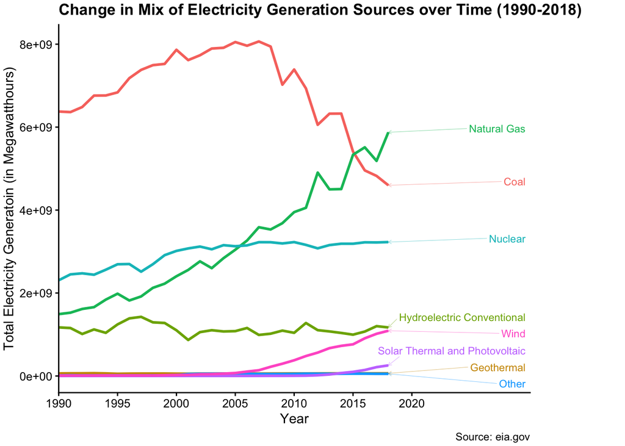

According to a report published from the Environmental protection Agency (EPA), the term, “Green Power” is defined as follows:

*“Green Power is also defined as renewable electricity that goes above and beyond what is otherwise required by mandate or requirement – green power is also voluntary or surplus to regulation. Renewable energy is supplied by natural resources that replenish themselves over short periods of time without being depleted. Green power is a subset of renewable energy and represents those renewable energy resources that provide the highest environmental benefit, such as: Solar, Wind, Geothermal (the earth’s heat), [and] Biomass (some forms of plant and waste material)…”*

In summation, clean energy is confirmed to be any renewable electricity generation source that naturally replenishes themselves over some period of time without becoming diminished. Specifically, some examples of “green” energy sourcing methods include solar, wind, geothermal, and biomass. While natural gas does not fit under the definition given above by the EPA, further research suggests that alternate (non-traditional) forms of natural gas are cleaner than coal, yet they do still produce some amount of carbon emissions.

Focusing in again on wind generation, the map of the United States below represents electricity generation due to wind in 1990. With California acting as the industry leader at the time, only seven states invested in wind electricity production.

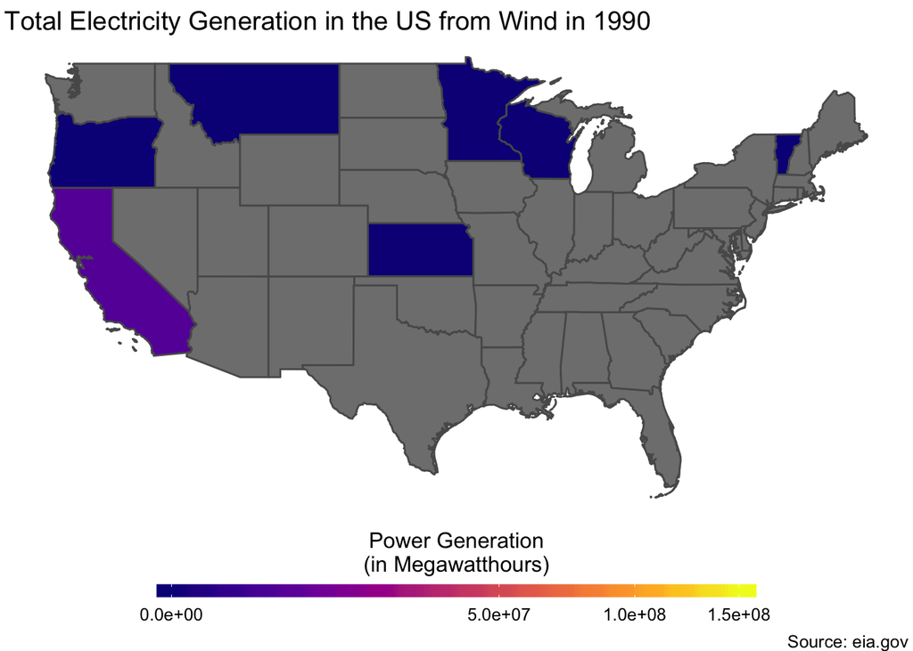

In contrast to the initial chloropleth map above, the total wind generation by each state within the US in 2018 is included below.

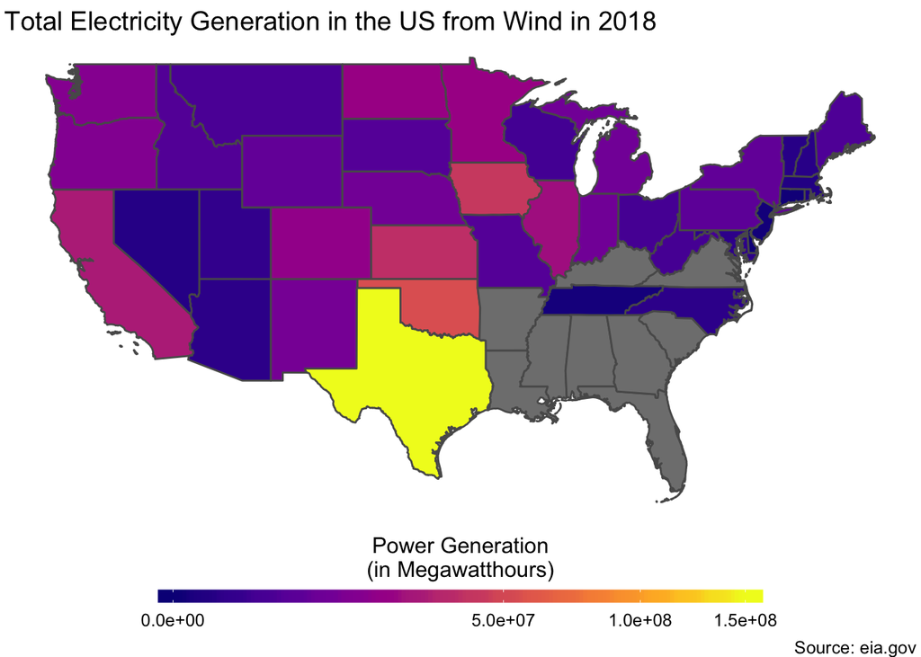

# Case Study: Change in Energy Generation in Texas (1990 - 2018)

Given that Texas is one of the largest electricity producing states within the US, a case study analyzing the change in the mix of generation sources between 1990 and 2018 is pictured below:

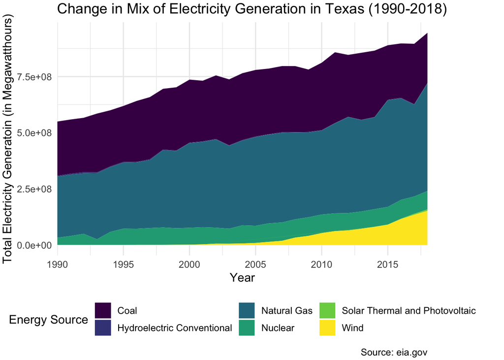

Based off of the result, one might gather that the total generation has been increasing rapidly over time due to an expanding population. As total production has been increasing, the mix has changed drastically; for example, in 1990, Texas produced approximately the same amount of electricity by using coal as they did natural gas. However, it is apparent that generation from coal has declined following the economic recession in 2008. As the economy was recovering, technological advancements were made, thus causing improvements in wind and natural gas which made them more heavily relied on.

# Correlation Analysis between State Investment and Wind Generation (2001-2003)

Upon conclusion of the analysis above, further thought suggests that there might exist some relationship between the amount of monetary contribution by state (per year) versus the production of electricity from clean energy sources (per year). To further the message being portrayed in the two chloropleth maps above, it is clear that over time, electricity production from wind has increased along with investment.

The plot below confirms this hypothesis as two data sets from the EIA were joined: one containing financial data by state from 2001 to 2003, and another which contains electricity generation data. Likewise, upon an in-depth process to clean and joining the data, total electricity generated from wind versus state investment were plotted and the results are seen below:

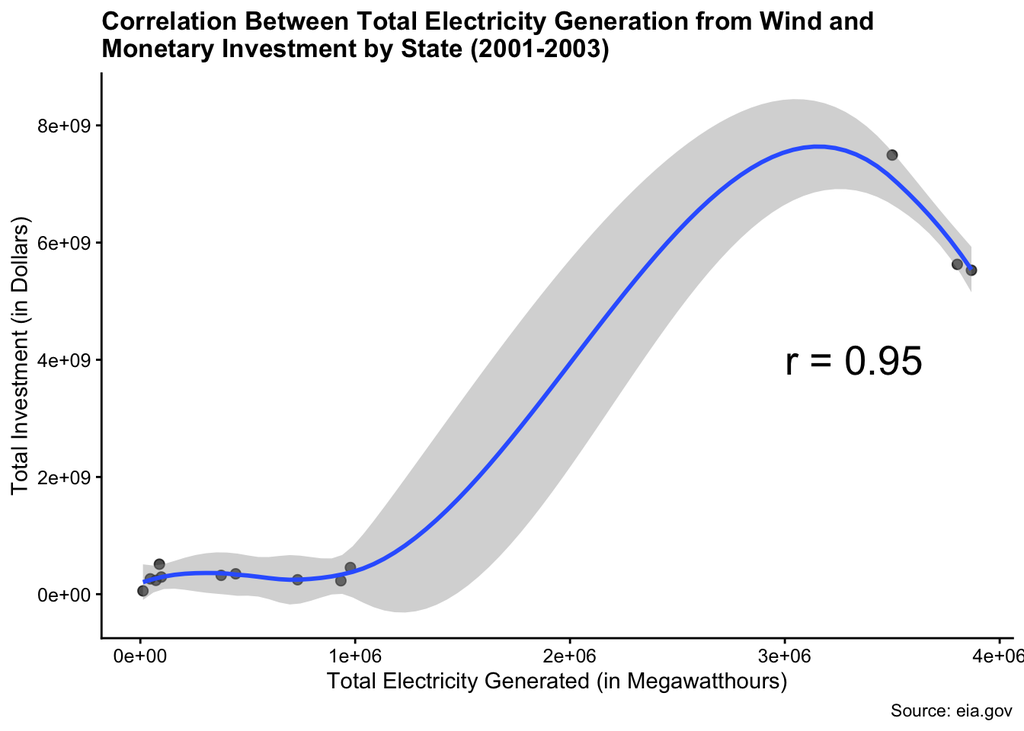

To summarize the findings from the plot above, there exists a strong direct relationship between wind electricity generation and investment by state. Likewise, it may be concluded that as investment increases, electricity generation from wind shall also increase. This relationship is supported by the “r” value which is equal to 95%, indicating a good fit for the data and thus, and strong correlation.

Future improvement for this plot might suggest more recent and complete data as the EIA does not currently hold conclusive financial data beyond 2003. In addition, it might be possible to include more data points so that there are not large gaps within the data.

# Future Motivation

Now that the evolution of the mix of electricity generation sources has been analyzed, case studies on top performing states have been performed, and correlation between investment and progress has been analyzed, there exists need to further this research. Future development might include an analysis regarding how the mix of sources have changed over time to accommodate a society which is becoming more reliant on electricity. For example, the market and demand for electric vehicles have risen greatly throughout the years, so one question might be: how are clean energy sourcing methods increasing capacity to accommodate for an expanding population and increased demand of electric goods?

# Appendix

**I. Net Generation by State by Type of Producer by Energy Source (EIA-906, EIA-920, and EIA-923)**

| Column Name | Description |
| --- | --- |
| Year (int) | Shows the year which the data was recorded |
| State (string) | Shows the state which the data was recorded |
| Type of Producer (string) | The industry where the electricity was generated. For example, electric generators, combined heat and power, etc. |
| Energy Source (string) | The energy source which was used to generate the electricity: coal, hydroelectric, natural gas, nuclear, wind, petroleum, etc. |
| Generation (double) | Shows the amount of electricity generated in megawatt hours (mwh) |

**II. Fossil Fuel Consumption for Electricity Generation by Year, Industry Type and State (EIA-906, EIA-920, and EIA-923)**

| Column Name | Description |
| --- | --- |
| Year (int) | Shows the year which the data was recorded |
| State (string) | Shows the state which the data was recorded |
| Type of Producer (string) | The industry where the electricity was generated. For example, electric generators, combined heat and power, etc. |
| Energy Source (Units) (string) | The energy source which was used to generate the electricity consumed. For example, coal, hydroelectric, natural gas, nuclear, wind, petroleum, etc. |
| Consumption for Electricity (double) | Shows the amount of electricity consumed in megawatt hours (mwh) |

**III. Financial Data on Publicly Owned Electric Utilities with Generation Facilities by State (EIA-412)**

| Column Name | Description |
| --- | --- |
| Year (int) | Shows the year which the data was recorded |
| State (string) | Shows the state which the data was recorded |
| Operating Revenue (int) | Currency generated in dollars per energy sourcing company |
| Operating Expenses (int) | The operating cost in dollars to run energy sources per company |
| Maintenance (int) | Cost (in dollars) to maintain energy generation facilities |
| Depreciation (int) | Depreciation (loss in value) per electricity generation company in dollars |
| Amortization (int) | Amortization cost in dollars per electricity generation source |
| Taxes (int) | Taxes spent in dollars per electricity generation source |
| Income (int) | Income earned per electricity generation plant (in dollars) |

# Works Cited

“Annual Report on US Wind Power Installation, Cost, and Performance Trends: 2007.” Nrel.gov, May 2008, www.nrel.gov/docs/fy08osti/43025.pdf.

“Guide to Purchasing Green Power.” Epa.gov, Environmental Protection Agency, Mar. 2010, www.epa.gov/sites/production/files/2016-01/documents/purchasing_guide_for_web.pdf.

“Is Natural Gas Renewable?” Is Natural Gas Renewable? | Vivint Solar Blog, www.vivintsolar.com/blog/is-natural-gas-renewable.

Zhou, Ella. “U.S. Renewable Energy Policy and Industry.” Nrel.gov, National Renewable Energy Laboratory , Oct. 2015, www.nrel.gov/docs/fy16osti/65255.pdf.